# ML Assignment - Predicting physical activities from sensor accelerometer data

Tomás A. Maccor

8/4/2020

## Background

Using devices such as Jawbone Up, Nike FuelBand, and Fitbit it is now possible to collect a large amount of data about personal activity relatively inexpensively.

One thing that people regularly do is quantify how much of a particular activity they do, **but they rarely quantify how well they do it**.

We will use data from 6 participants of a research project. They had 4 accelerometers placed on their bodies in the following locations:

- in a belt they were wearing
- forearm
- arm, &
- in the dumbbell they used for the exercise

**They were asked to perform *dumbbell* lifts correctly and incorrectly in 5 different ways**. More information on this experiment is available from the website here: http://web.archive.org/web/20161224072740/http:/groupware.les.inf.puc-rio.br/har

The 5 different ways of perfoming the exercise were captured in the variable **“classe”** of the above referenced dataset.

The goal of this project is to predict the manner in which they did the exercise, using the Machine Learning Model with the best accuracy (to predict).

## Exploratory Data Analysis & data processing

We download the data & perform some preliminary exploration:

Original_trainingset (**training set**) contains 19622 observations from 160 variables  
The **validation** dataset contains 20 observations from 160 variables

unique(original_trainingset$user_name) 6 names in the “user_name” variable – the # of users corresponds to the 6 volunteers

There are some **continuous** numerical variables that were read into R as character variables –if we use these variables in our ML algorithm, we will have to transform them appropriately.

We now explore if there is missing values (data) in the dataset:

```r
TOTAL_NA_values <- sum(is.na(original_trainingset))
```

The % of NA values in the DF is high —->

```
## [1] "61.21%"
```

If we further review the ORIGINAL TRAINING DATASET, there are many columns that always have NA values -except for ROWS where the *“new_window”* variable = “yes”. Of note, there are error values in these rows as well: **“#DIV/0!”**.

So we will remove these columns that have NA values –they have summary statistics data, this is data of a different nature than the raw data that is prevalent in the dataset. We could try to use them as FEATURES for our MODEL #2.

```r
training_clean <- original_trainingset[ , colSums(is.na(original_trainingset)) == 0]
## glimpse(training_clean)
```

This leaves us with a dataset (*training_clean*) containing 60 variables, where all but 2 are NUMERIC/DOUBLE -exceptions are the CLASSE variable (which we wont use for modelling) & user_name —which we dont mind since it also wont be part of the data to be fed to the ML model.

So, now we can start splitting our CLEAN TRAINING dataset to start trying out various ML models:

```r
set.seed(7)
traindex <- createDataPartition(training_clean$classe,p = 0.7,list = FALSE)
train <- training_clean[traindex,]
test <- training_clean[-traindex,]
```

# 1. MODEL FITTING - using dataset with **RAW** data

If we want to use MODEL-BASED prediction, variables have to have Gaussian distribution  
Let’s explore if our variables have this distribution  
We’ll explore the variables associated with the BELT sensor:

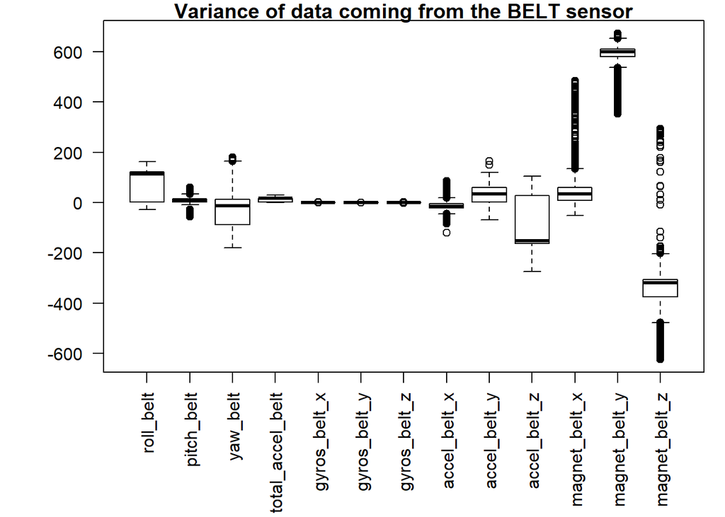

```r
outliers_belt <- select(training_clean, contains("belt"))
par(mar=c(7,5,1,1))
boxplot(outliers_belt, main = "Variance of data coming from the BELT sensor", las=2)
```

Seems to be quite a big data spread (variance) in the belt-related data that was collected.  
Let’s check the density distribution of 2-3 variables related to belt, just in case:

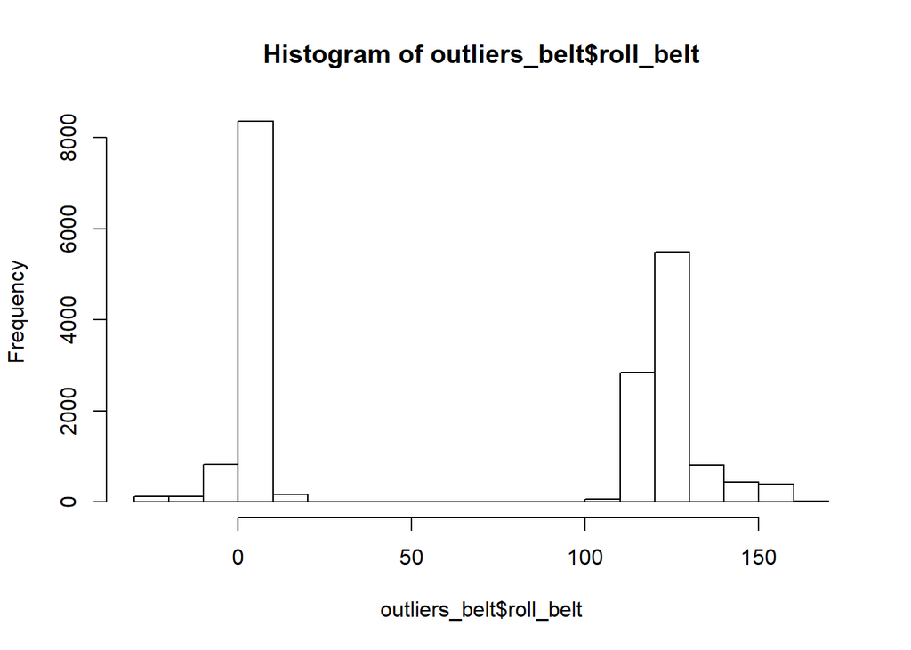

```r
hist(outliers_belt$roll_belt)
```

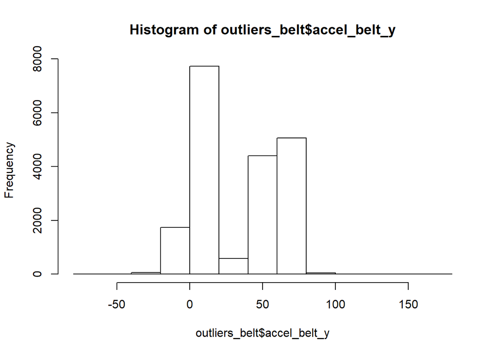

```r
hist(outliers_belt$accel_belt_y)
```

We determine that the variables in the dataset which we want to feed in to the ML normal do not have a normal distribution.

Therefore:  
1. We can’t use model-based ML algorithms (GAMs, polynomial or logistic regression for example)  
2. We also cannot preprocess with PCA —> as the data has way to many outliers for PCA to perform efficiently

We also check if there are Near Zero covariates:  
*nearZeroVar(train[ , 8:59 ], saveMetrics = TRUE)*  
and there’s none.

From literature search (references below), **Random Forest, SVM & k-NN seem to be amongst the ML-learning algorithms that best perform with accelerometer data**:

- (Zdravevski E, Risteska Stojkoska B, Standl M, Schulz H (2017) - *Automatic machine learning based identification of jogging periods from accelerometer measurements of adolescents under field conditions.* **PLoS ONE 12(9): e0184216. https://doi.org/10.1371/journal.pone.0184216**
- Andrea Mannini, Angelo Maria Sabatini (2010) - *Machine Learning Methods for Classifying Human Physical Activity from On-Body Accelerometers.* **Sensors 2010, 10, 1154-1175. Doi:10.3390/s100201154**

Here we will apply the Random Forest & SVM algorithms, and we will also compare them with boosting for RF.

## 1.a - Random Forest algorithm

```r
### Using RANDOM FOREST  --all 59 predictors
RF_fit <- train(classe ~ . , data=train[ , -c(1:7)],method="rf")
RF_fit$finalModel
```

```
##
## Call:
##  randomForest(x = x, y = y, mtry = param$mtry)
##                Type of random forest: classification
##                      Number of trees: 500
## No. of variables tried at each split: 2
##
##         OOB estimate of  error rate: 0.64%
## Confusion matrix:
##      A    B    C    D    E  class.error
## A 3904    2    0    0    0 0.0005120328
## B   11 2641    6    0    0 0.0063957863
## C    0   19 2374    3    0 0.0091819699
## D    0    0   39 2211    2 0.0182060391
## E    0    0    1    5 2519 0.0023762376
```

```r
pred_test_RF <- predict(RF_fit, test)
confusionMatrix(pred_test_RF, test$classe)
```

```
## Confusion Matrix and Statistics
##
##           Reference
## Prediction    A    B    C    D    E
##          A 1672    7    0    0    0
##          B    2 1128    7    0    0
##          C    0    4 1018   15    0
##          D    0    0    1  948    8
##          E    0    0    0    1 1074
##
## Overall Statistics
##
##                Accuracy : 0.9924
##                  95% CI : (0.9898, 0.9944)
##     No Information Rate : 0.2845
##     P-Value [Acc > NIR] : < 2.2e-16
##
##                   Kappa : 0.9903
##
##  Mcnemar's Test P-Value : NA
##
## Statistics by Class:
##
##                      Class: A Class: B Class: C Class: D Class: E
## Sensitivity            0.9988   0.9903   0.9922   0.9834   0.9926
## Specificity            0.9983   0.9981   0.9961   0.9982   0.9998
## Pos Pred Value         0.9958   0.9921   0.9817   0.9906   0.9991
## Neg Pred Value         0.9995   0.9977   0.9983   0.9968   0.9983
## Prevalence             0.2845   0.1935   0.1743   0.1638   0.1839
## Detection Rate         0.2841   0.1917   0.1730   0.1611   0.1825
## Detection Prevalence   0.2853   0.1932   0.1762   0.1626   0.1827
## Balanced Accuracy      0.9986   0.9942   0.9941   0.9908   0.9962
```

The variables most important for splitting the data were the BELT sensor *roll* & *yaw* variables, followed by the *magnet* data from the DUMBBELL:

```r
varImp(RF_fit)
```

```
## rf variable importance
##
##   only 20 most important variables shown (out of 52)
##
##                   Overall
## roll_belt          100.00
## yaw_belt            81.06
## magnet_dumbbell_z   67.28
## pitch_forearm       62.65
## magnet_dumbbell_y   62.52
## pitch_belt          59.44
## magnet_dumbbell_x   50.92
## roll_forearm        48.80
## accel_dumbbell_y    45.34
## accel_belt_z        43.86
## magnet_belt_z       43.62
## roll_dumbbell       42.53
## magnet_belt_y       41.24
## accel_dumbbell_z    36.53
## accel_forearm_x     33.85
## roll_arm            31.64
## magnet_arm_y        29.79
## yaw_dumbbell        28.92
## gyros_dumbbell_y    28.70
## accel_dumbbell_x    28.57
```

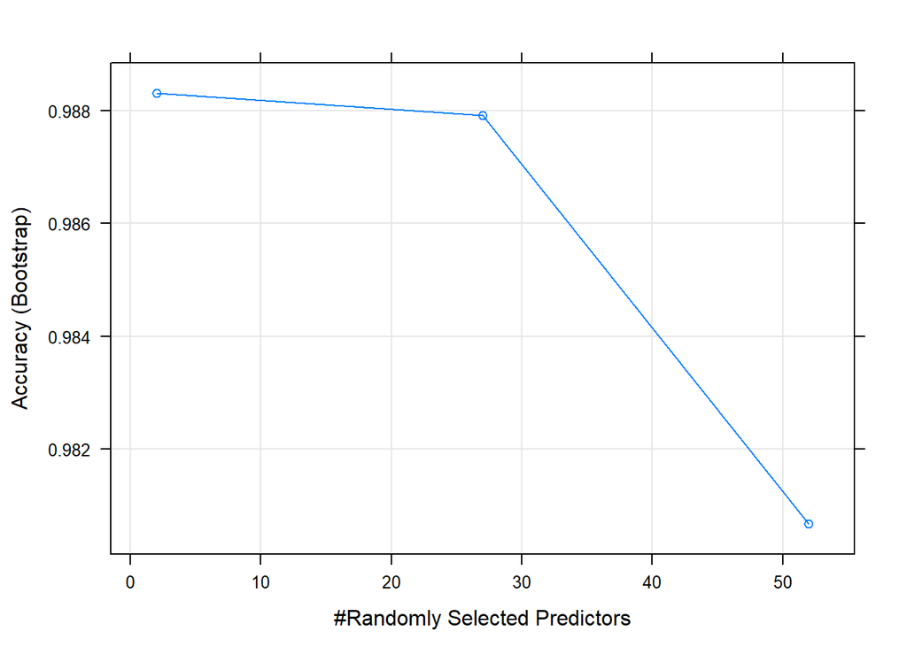

```r
plot(RF_fit)
```